# RNAEditingAnalysisTutorial

```r
library(RNAEditingAnalysisTools)
```

This package provides tools to import RNA editing data from REDItools, conduct quality control and strand correction, get summary statistics, and conduct differential RNA Editing analysis.

# Merging Data from Multiple Files into One Data Set

REDItools and other RNA editing analysis tools typically report RNA editing rates by individual, with an output of one file per sample. Consequently, in order to analyze RNA editing at the population level or to do differential editing analyses, we first have to merge these files together.

We can merge individual RNA editing results using the MergeIndividualFiles function from the package, MultiDataAnalysis. The MergeIndividualFiles function reads in files containing data from individual samples and merges individual data into one dataset by variable or measurement.

For this example, we will use data that has been installed with the MultiDataAnalysis package in the extdata/ folder. You can also download these files directly from github: https://github.com/okg3/MultiDataAnalysis/tree/master/inst/extdata

We will be looking at example output from a REDItools Denovo analysis with 8 samples.

```r
# set dirPath to extdata directory in package path
dirPath <- paste0(path.package("MultiDataAnalysis"), "/extdata/")
```

```r
dirPath
```

```
#> [1] "C:/Users/ogard/Documents/R/win-library/3.5/MultiDataAnalysis/extdata/"
```

```r
# Data is split into separate files by sample
list.files(dirPath, pattern = ".txt.gz")
```

```
#> [1] "sample1.txt.gz" "sample2.txt.gz" "sample3.txt.gz" "sample4.txt.gz"
#> [5] "sample5.txt.gz" "sample6.txt.gz" "sample7.txt.gz" "sample8.txt.gz"
```

Let’s load one file to look at values:

```r
file1 <- data.table::fread(paste0(dirPath, "sample1.txt.gz"))
head(file1)
```

```
#>    Region  Position Reference Strand RepMask_feat RepMask_gid
#> 1:  chr10 100233036         T      1         SINE       AluJo
#> 2:  chr10 100233053         T      1         SINE       AluJo
#> 3:  chr10 101789717         T      1         SINE       AluJb
#> 4:  chr10 101789723         T      1         SINE       AluJb
#> 5:  chr10 101789782         T      1         SINE       AluJb
#> 6:  chr10 101789903         T      1         SINE       AluJb
#>             RefSeq_feat RefSeq_gid RADAR_feat RADAR_gid DARNED_feat DARNED_gid
#> 1: 3UTR,exon,transcript    CWF19L1       3UTR   CWF19L1           .    CWF19L1
#> 2: 3UTR,exon,transcript    CWF19L1       3UTR   CWF19L1           .    CWF19L1
#> 3:           transcript        OGA   intronic     MGEA5           .      MGEA5
#> 4:           transcript        OGA   intronic     MGEA5           .      MGEA5
#> 5:           transcript        OGA   intronic     MGEA5           .      MGEA5
#> 6:           transcript        OGA   intronic     MGEA5           .      MGEA5
#>    REDIportal_feat REDIportal_gid AllSubs Coverage-q25 MeanQ BaseCount[A,C,G,T]
#> 1:  ncRNA_intronic  RP11-316M21.6      TC           27 38.26      [0, 8, 0, 19]
#> 2:  ncRNA_intronic  RP11-316M21.6      TC           27 36.89      [0, 6, 0, 21]
#> 3:        intronic          MGEA5      TC           71 38.69     [0, 14, 0, 57]
#> 4:        intronic          MGEA5      TC           66 37.62     [0, 34, 0, 32]
#> 5:        intronic          MGEA5      TC           46 38.24     [1, 17, 0, 28]
#> 6:        intronic          MGEA5      TC           72 37.85     [0, 16, 0, 56]
#>    Frequency       Pvalue
#> 1:      0.30 1.215299e-02
#> 2:      0.22 5.014270e-02
#> 3:      0.20 2.631754e-04
#> 4:      0.52 4.167670e-12
#> 5:      0.38 1.355112e-05
#> 6:      0.22 5.983720e-05
```

In this data, the unique editing events are identified by the columns Region, Position, Reference, and Strand.

```r
idCols <- c("Region", "Position", "Reference", "Strand")
```

The columns AllSubs, Coverage-q25, MeanQ, BaseCount[A,C,G,T], Frequency, and Pvalue all represent individual meansurements that are specific to this sample. In order to compare measurements across samples, we will want to combine all of the Frequency columns from different samples into one matrix, all Coverage columns into another matrix, etc.

```r
IndVars <- c("AllSubs", "Coverage-q25", "MeanQ", "BaseCount[A,C,G,T]",
             "Frequency", "Pvalue")
```

The remaining columns are annotations of the unique editing events which we will want to keep in a separate annotation data.frame.

To combine these datasets, we will use the MergeIndividualFiles function:

```r
RNAEdData <- MergeIndividualFiles(
  fileDirectory = dirPath,
  filePattern = ".txt.gz",
  indVars = IndVars,
  IDcol = idCols,
  na.strings = "-"
)
names(RNAEdData)
```

```
#> [1] "Annotation"         "AllSubs"            "Coverage-q25"
#> [4] "MeanQ"              "BaseCount[A,C,G,T]" "Frequency"
#> [7] "Pvalue"
```

Our merged dataset is a list containing one Annotation data.frame and 6 matrices with individual sample values for the 6 variables defined in indVars.

```r
head(RNAEdData$Annotation)
```

```
#>                     id Region  Position Reference Strand RepMask_feat
#> 1: chr10_100233036_T_1  chr10 100233036         T      1         SINE
#> 2: chr10_100233053_T_1  chr10 100233053         T      1         SINE
#> 3: chr10_101789717_T_1  chr10 101789717         T      1         SINE
#> 4: chr10_101789723_T_1  chr10 101789723         T      1         SINE
#> 5: chr10_101789782_T_1  chr10 101789782         T      1         SINE
#> 6: chr10_101789903_T_1  chr10 101789903         T      1         SINE
#>    RepMask_gid          RefSeq_feat RefSeq_gid RADAR_feat RADAR_gid DARNED_feat
#> 1:       AluJo 3UTR,exon,transcript    CWF19L1       3UTR   CWF19L1           .
#> 2:       AluJo 3UTR,exon,transcript    CWF19L1       3UTR   CWF19L1           .
#> 3:       AluJb           transcript        OGA   intronic     MGEA5           .
#> 4:       AluJb           transcript        OGA   intronic     MGEA5           .
#> 5:       AluJb           transcript        OGA   intronic     MGEA5           .
#> 6:       AluJb           transcript        OGA   intronic     MGEA5           .
#>    DARNED_gid REDIportal_feat REDIportal_gid
#> 1:    CWF19L1  ncRNA_intronic  RP11-316M21.6
#> 2:    CWF19L1  ncRNA_intronic  RP11-316M21.6
#> 3:      MGEA5        intronic          MGEA5
#> 4:      MGEA5        intronic          MGEA5
#> 5:      MGEA5        intronic          MGEA5
#> 6:      MGEA5        intronic          MGEA5
```

```r
head(RNAEdData$Frequency)
```

```
#>                     sample1 sample2 sample3 sample4 sample5 sample6 sample7
#> chr10_100233036_T_1    0.30    0.33    0.26    0.30    0.22    0.25    0.23
#> chr10_100233053_T_1    0.22    0.47    0.25    0.50    0.30    0.52    0.38
#> chr10_101789717_T_1    0.20    0.19    0.21    0.29    0.35    0.26    0.30
#> chr10_101789723_T_1    0.52    0.54    0.48    0.53    0.66    0.71    0.56
#> chr10_101789782_T_1    0.38    0.43    0.41    0.33    0.49    0.62    0.40
#> chr10_101789903_T_1    0.22    0.29    0.38    0.30    0.41    0.28    0.28
#>                     sample8
#> chr10_100233036_T_1    0.29
#> chr10_100233053_T_1    0.32
#> chr10_101789717_T_1    0.20
#> chr10_101789723_T_1    0.57
#> chr10_101789782_T_1    0.55
#> chr10_101789903_T_1    0.34
```

Each matrix has 8 columns names after the file names, after removing the pattern defined in filePattern. Matrix rownames match the id column in the Annotation data.frame.

# RNA Editing QC and Global Descriptors

## Strand Correction and Calculating Edited Reads

Once this data has been merged, we first want to check strand calling:

```r
RNAEdDataQCed <- StrandCorrection(x = RNAEdData, genes = "RefSeq_gid")
```

We are also going to add a matrix with raw counts of edited reads for every site in each sample to be used later for global editing analyses:

```r
RNAEdDataQCed <- GetEditedReads(RNAEdDataQCed)
head(RNAEdDataQCed$EditedReads)
```

```
#>                     sample1 sample2 sample3 sample4 sample5 sample6 sample7
#> chr10_100233036_A_0       8      14      10      19      19      20      16
#> chr10_100233053_A_0       6      22       8      27      26      38      26
#> chr10_101789717_A_0      14      12      20      15      43      13      39
#> chr10_101789723_A_0      34      33      44      25      82      35      71
#> chr10_101789782_A_0      17      23      23      13      42      25      38
#> chr10_101789903_A_0      16      21      34      15      32      13      44
#>                     sample8
#> chr10_100233036_A_0      18
#> chr10_100233053_A_0      19
#> chr10_101789717_A_0      20
#> chr10_101789723_A_0      55
#> chr10_101789782_A_0      42
#> chr10_101789903_A_0      27
```

## Global Descriptors

Now that the data has been prepared, we can look at global descriptors including:

- Percent A>G substitutions versus other substitution types
- Genomic regions with editing
- Percent in Alu repeat regions
- Percent reported in one or more databases
- Overall frequency of editing

### Substitution Types

The vast majority of RNA editing events should be of the canonical A>G type and then the C>T type. While StrandCorrection above should have addresses most strand calling errors, we may also see a larger proportion of T>C and G>A substitutions. We get the proportions of each using the SubType column in our Annotation data.frame:

```r
subtypeCounts <- table(RNAEdDataQCed$Annotation$SubType)
subtypeCounts
```

```
#>
#>  AC  AG  AT  CA  CT  TC
#>   1 957   1   2   2  37
```

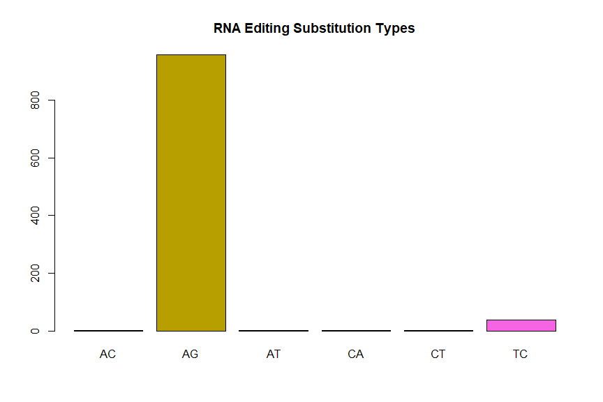

```r
barplot(subtypeCounts, col = gg_color_hue(length(subtypeCounts)),
        main = "RNA Editing Substitution Types")
```

To visualize as a donut plot, let’s reorder substitution types by count:

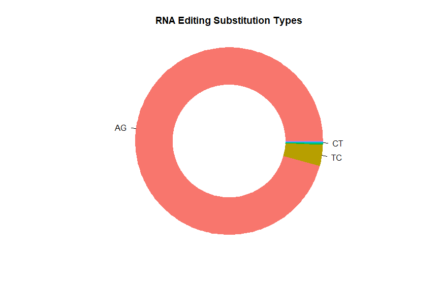

```r
subtypeCounts <- subtypeCounts[order(subtypeCounts, decreasing = TRUE)]
subtypeLabels <- names(subtypeCounts)
subtypeLabels[-grep("AG|CT|TC|GA", subtypeLabels)] <- NA
donut(subtypeCounts, labels = subtypeLabels, outer.radius = 1,
      main = "RNA Editing Substitution Types")
```

Alternatively, to get substitution types from the AllSubs matrix without running strand correction, we can use the GetSubType function:

```r
# Get consensus substitution type from AllSubs matrix
SubType <- GetSubType(RNAEdData$AllSubs)
subtypeCounts <-table(SubType)
subtypeCounts
```

```
#> SubType
#>  AC  AG  AT  CA  CT  GA  TC
#>   1 434   1   2   1   1 560
```

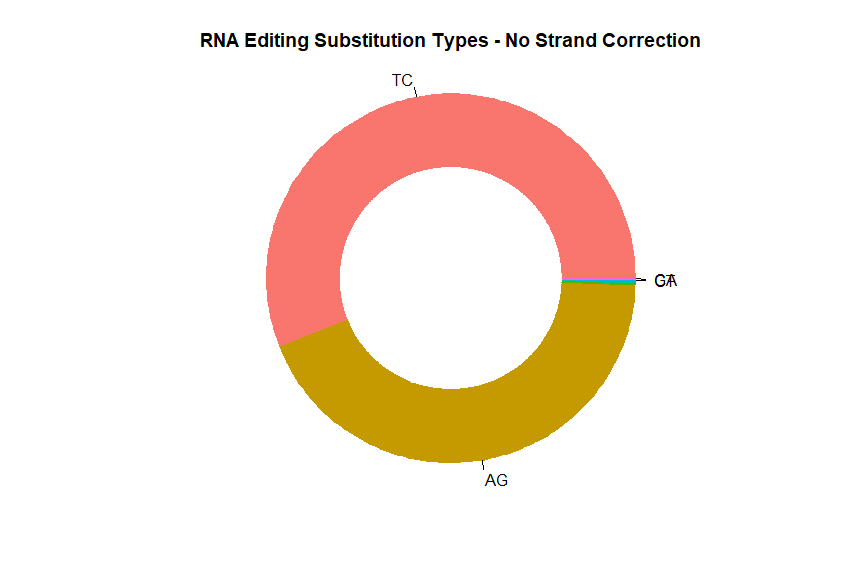

```r
# Donut plot
subtypeCounts <- subtypeCounts[order(subtypeCounts, decreasing = TRUE)]
subtypeLabels <- names(subtypeCounts)
subtypeLabels[-grep("AG|CT|TC|GA", subtypeLabels)] <- NA
donut(subtypeCounts, labels = subtypeLabels, outer.radius = 1,
      main = "RNA Editing Substitution Types - No Strand Correction")
```

As you can see, the majority of editing events are about evenly split between AG and TC without strand correction.

### Genomic Regions with Editing

Most RNA editing events tend to be non-coding. To look at the genomic distribution of RNA editing events, we can use the GetGeneRegion function:

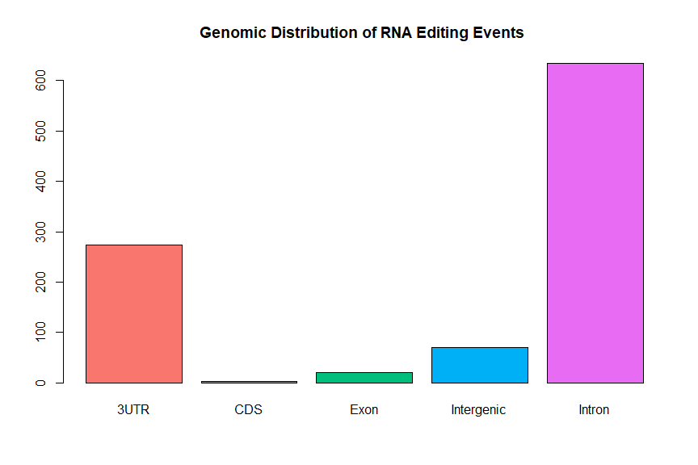

```r
regions <- GetGeneRegion(RNAEdDataQCed$Annotation$RefSeq_feat)
regionCounts <- table(regions)

barplot(regionCounts, col = gg_color_hue(length(regionCounts)),
        main = "Genomic Distribution of RNA Editing Events ")
```

As we can see, the majority of RNA editing events fall in intronic regions, followed by the 3’UTR.

### Alu Repeat Regions

RNA editing events, especially A>G events, most frequently appear in Alu repeat regions. We can look at the distribution of RNA editing events in Alu and non-Alu repetitive elements using the GetAluRepeat function:

```r
aluRepeats <- GetAluRepeat(RNAEdDataQCed$Annotation$RepMask_gid)
aluCounts <- table(aluRepeats)
aluCounts
```

```
#> aluRepeats
#>                    Alu         Non-Alu Repeat Non-Repetitive Element
#>                    884                     61                     55
```

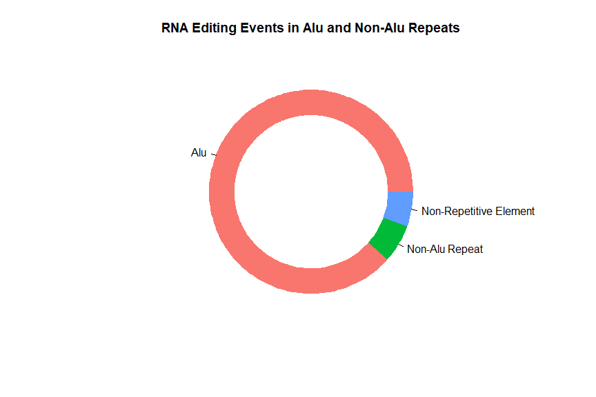

```r
donut(aluCounts, main = "RNA Editing Events in Alu and Non-Alu Repeats")
```

As expected, about 88% of the RNA editing events are in Alu repeat regions.

We can also look specifically at A>G substitutions and find similar results:

```r
aluRepeats <- GetAluRepeat(RNAEdDataQCed$Annotation$RepMask_gid[
  RNAEdDataQCed$Annotation$SubType == "AG"
])
aluCounts <- table(aluRepeats)
aluCounts
```

```
#> aluRepeats
#>                    Alu         Non-Alu Repeat Non-Repetitive Element
#>                    846                     60                     51
```

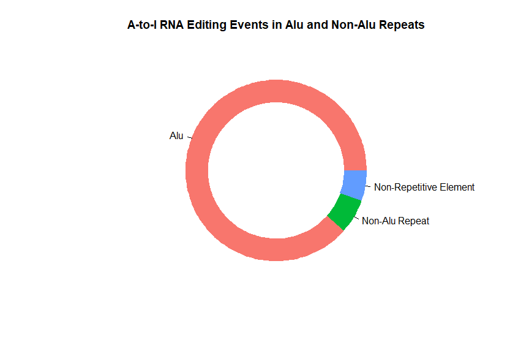

```r
donut(aluCounts, main = "A-to-I RNA Editing Events in Alu and Non-Alu Repeats")
```

### RNA Editing Databases

Finally, we may want to check what percent of our editing events are novel vs. previously reported in an RNA editing database such as RADAR, DARNED, or REDIportal. We can count how many databases report an editing event using the function CheckDatabase:

```r
db <- CheckDatabase(RNAEdDataQCed$Annotation$RADAR_gid,
                    RNAEdDataQCed$Annotation$DARNED_gid,
                    RNAEdDataQCed$Annotation$REDIportal_gid)

dbCount <- table(db)
dbCount
```

```
#> db
#>   0   1   2   3
#>  23  32 310 635
```

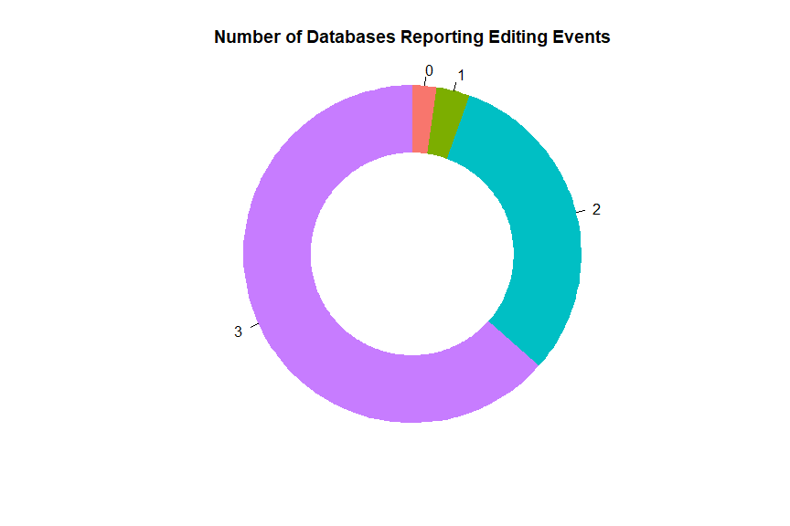

```r
donut(x = dbCount, clockwise = TRUE, outer.radius = 1,
      main = "Number of Databases Reporting Editing Events")
```

As we can see, the vast majority of our RNA editing events have previously been reported, which increases our confidence that these are real.

### Frequency of Editing

Finally, we may want to look at the overall distribution of editing frequencies (e.g. what percent of reads mapping to a site have the edit). We can summarize this data using the SummarizeData function from the MultiDataAnalysis package and then plot:

```r
freqSummary <- SummarizeData(as.numeric(RNAEdDataQCed$Frequency), na.rm = TRUE)
round(freqSummary, 3)
```

```
#>          N percent_NA  percent_0       mean         sd         se        var
#>   8000.000      0.000      0.000      0.366      0.177      0.002      0.031
#>        min quartile_1     median quartile_3        max
#>      0.100      0.230      0.330      0.470      1.000
```

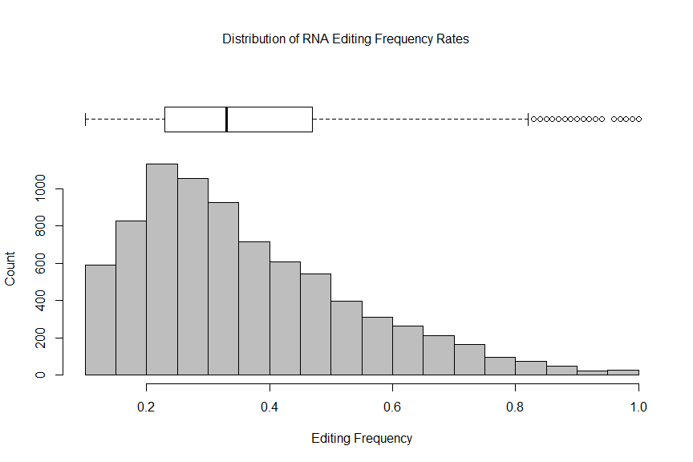

```r
par(fig= c(0,1,0.5,0.95))
boxplot(as.numeric(RNAEdDataQCed$Frequency), horizontal = TRUE,
        axes = FALSE)
par(fig= c(0,1,0,0.8), new = TRUE)
hist(as.numeric(RNAEdDataQCed$Frequency),
     xlab = "Editing Frequency",
     ylab = "Count",
     main = NULL,
     col = "grey")
mtext("Distribution of RNA Editing Frequency Rates",
      side=3, outer=TRUE, line=-3)
```

## Global Editing Values by Sample

Now that we have checked the overall distribution of RNA editing events, let’s look at global RNA Editing measures by individual.

For this, there are two main measures we are interested in:

- The proportion of edited reads over the total number of reads mapping to edited sites (proportion)
- The total number of sites that are edited in that individual (count)

If there are substantial differences in the quality of coverage, we may want to normalize the individual count by the total number of sites that are covered (coverage).

```r
globalEd <- GlobalEditing(RNAEdDataQCed)
globalEd
```

```
#> $proportion
#>   sample1   sample2   sample3   sample4   sample5   sample6   sample7   sample8
#> 0.3301514 0.3369879 0.3355124 0.3455418 0.3414304 0.3220597 0.3495448 0.3390704
#>
#> $count
#> sample1 sample2 sample3 sample4 sample5 sample6 sample7 sample8
#>    1000    1000    1000    1000    1000    1000    1000    1000
#>
#> $covered
#> sample1 sample2 sample3 sample4 sample5 sample6 sample7 sample8
#>    1000    1000    1000    1000    1000    1000    1000    1000
```

In this case, all edited sites have at least some editing in all of our samples, so we will use the proportion measure alone:

```r
globalProp <- GlobalEditing(RNAEdDataQCed, type = "proportion")
globalProp
```

```
#>   sample1   sample2   sample3   sample4   sample5   sample6   sample7   sample8
#> 0.3301514 0.3369879 0.3355124 0.3455418 0.3414304 0.3220597 0.3495448 0.3390704
```

We can then use this to test for differences in global editing proportion between groups:

```r
RNAEdSampleInfo
```

```
#>     sample age  status batch
#> 1: sample1  71    case     a
#> 2: sample2  76    case     b
#> 3: sample3  73    case     a
#> 4: sample4  71 control     b
#> 5: sample5  73 control     a
#> 6: sample6  75    case     b
#> 7: sample7  68 control     a
#> 8: sample8  84 control     b
```

```r
# Test if global editing proportion differs by batch
batch <- as.factor(RNAEdSampleInfo$batch)
out <- lm(globalProp ~ batch)
summary(out)$coefficients
```

```
#>                 Estimate  Std. Error    t value     Pr(>|t|)
#> (Intercept)  0.339159770 0.004578991 74.0686650 4.076154e-10
#> batchb      -0.003244816 0.006475672 -0.5010778 6.341650e-01
```

```r
# Test if global editing proportion differs by case control status
status <- as.factor(RNAEdSampleInfo$status)
out <- lm(globalProp ~ status)
summary(out)$coefficients
```

```
#>                 Estimate  Std. Error    t value     Pr(>|t|)
#> (Intercept)   0.33117785 0.002891957 114.516862 2.989274e-11
#> statuscontrol 0.01271903 0.004089845   3.109906 2.085135e-02
```

We can see that global editing rates do not differ significantly by sequencing batch but are significantly lower in cases than in controls.

We can also use the GlobalEditing function to find proportions by substitution type or other column in the Annotation data.frame:

```r
globalSub <- GlobalEditing(RNAEdDataQCed, type = "proportion", by = "SubType")
globalSub
```

```
#>      sample1   sample2   sample3   sample4   sample5   sample6   sample7
#> AG 0.3307215 0.3381900 0.3363241 0.3466274 0.3422902 0.3233091 0.3500535
#> TC 0.3317923 0.2956587 0.3214636 0.3138152 0.3077694 0.2992187 0.3298583
#> CA 0.1241379 0.2347826 0.1779141 0.1818182 0.1216216 0.1390374 0.2500000
#> AT 0.3939394 0.5357143 0.5600000 0.3773585 1.0000000 0.4736842 1.0000000
#> CT 0.1503759 0.2142857 0.1824818 0.2622951 0.2787879 0.2173913 0.2229730
#> AC 0.2666667 1.0000000 0.4736842 0.4754098 0.9879518 0.4038462 1.0000000
#>      sample8
#> AG 0.3397842
#> TC 0.3163112
#> CA 0.2142857
#> AT 0.4736842
#> CT 0.1496063
#> AC 0.9791667
```

```r
globalAG <- globalSub["AG", ]
out <- lm(globalAG ~ status)
summary(out)$coefficients
```

```
#>                 Estimate  Std. Error    t value     Pr(>|t|)
#> (Intercept)   0.33213617 0.002861029 116.089743 2.754440e-11
#> statuscontrol 0.01255266 0.004046107   3.102405 2.105178e-02
```

To calculate overall editing by gene:

```r
geneEd <- GlobalEditing(RNAEdDataQCed, type = "proportion", by = "RefSeq_gid")
head(geneEd)
```

```
#>           sample1   sample2   sample3   sample4   sample5   sample6   sample7
#> CWF19L1 0.2592593 0.4044944 0.2571429 0.3931624 0.2616279 0.3790850 0.3021583
#> OGA     0.2804504 0.2734864 0.3348175 0.2748447 0.3631769 0.3698854 0.2878953
#> NT5C2   0.2705411 0.2633229 0.2747748 0.2500000 0.2829670 0.2088608 0.3099688
#> WDR37   0.8421053 0.5200000 0.6842105 0.3928571 0.3939394 0.4705882 0.6744186
#> BBIP1   0.3428571 0.4285714 0.3720930 0.2926829 0.3333333 0.1851852 0.3968254
#> CELF2   0.3243243 0.4966443 0.3091787 0.4237288 0.3455497 0.1764706 0.3125000
#>           sample8
#> CWF19L1 0.3057851
#> OGA     0.2904564
#> NT5C2   0.2798265
#> WDR37   0.6379310
#> BBIP1   0.4210526
#> CELF2   0.3292683
```

# Differential RNA Editing

To test for associations between RNA Editing and a trait at every edited site, we can use the ModelMultiData function from the MultiDataAnalysis package. The ModelMultiData function applies a regression model across all rows of one or more matrices with inputs from multiple data sets and returns the summary regression coefficients.

## Association between RNA Editing at Each Site and Age

First, let’s test if RNA Editing frequency at any site is associated with age using a linear model, adjusting for batch. To do this, we supply the RNA Editing Frequency matrix to x and the RNAEdSampleInfo data.frame to groups. Because we don’t want to include status as a covariate, we will add that to the excludeVars parameter.

```r
out <- ModelMultiData(x = RNAEdDataQCed$Frequency, groups = RNAEdSampleInfo,
                      excludeVars = "status")
out <- out[order(out$fdr), ]
head(out)
```

```
#>                    x1 variable  Estimate Std. Error   t value       pValue
#> 1: chr16_67995842_A_0       x1 -63.67663  11.222047 -5.674244 0.0023665318
#> 2:  chr1_36478030_A_0       x1 -62.45989  11.160877 -5.596325 0.0025154764
#> 3: chr2_200994412_A_0       x1 -39.02631   5.248331 -7.435947 0.0006933415
#> 4:  chr2_40200622_A_0       x1 -47.16647   7.380685 -6.390528 0.0013897464
#> 5: chr11_65442619_A_1       x1 -73.67576  16.502177 -4.464609 0.0066121749
#> 6:  chr12_9659679_A_1       x1 106.46259  24.712236  4.308092 0.0076564632
#>          fdr
#> 1: 0.6288691
#> 2: 0.6288691
#> 3: 0.6288691
#> 4: 0.6288691
#> 5: 0.8507181
#> 6: 0.8507181
```

By default, if no formula is provided, ModelMultiData will build a formula using the provided data. If groups is defined and y is not, then the left-hand variable defaults to the second column of groups after applying excludeVars and includeVars. The remaining columns in groups post-includsion/exclusion criteria are included as covariates in the model. We can also supply the formula directly, as seen below.

## Association between RNA Editing at Each Site and Case Control Status

While ModelMultiData applies a linear model by default, we can also test binary traits with a logistic regression by changing the FUN parameter to glm and supplying family = binomial(). Here, we are interested in testing for associations between RNA Editing Frequency and case-control status, so we supply the formula status ~ frequency and note that “frequency” refers to the rows of our x matrix (RNAEdDataQCed$Frequency) by setting xName.

```r
out <- ModelMultiData(formula = status ~ frequency, x = RNAEdDataQCed$Frequency,
                      groups = RNAEdSampleInfo, xName = "frequency",
                      FUN = glm, family = binomial())

out <- out[order(out$fdr), ]
head(out)
```

```
#>              frequency  variable    Estimate Std. Error    z value    pValue
#> 1: chr10_100233036_A_0 frequency  -20.843614   22.02754 -0.9462524 0.3440199
#> 2: chr10_101789717_A_0 frequency   31.895556   20.77391  1.5353664 0.1246939
#> 3: chr10_101789903_A_0 frequency   13.523230   14.38668  0.9399826 0.3472265
#> 4: chr10_101810887_A_0 frequency -109.545570   84.87162 -1.2907209 0.1968005
#> 5: chr10_101810918_A_0 frequency  -21.437569   20.85311 -1.0280275 0.3039369
#> 6: chr10_101811186_A_0 frequency    8.111318   13.12262  0.6181171 0.5364982
#>         fdr
#> 1: 0.936858
#> 2: 0.936858
#> 3: 0.936858
#> 4: 0.936858
#> 5: 0.936858
#> 6: 0.936858
```

## Association between RNA Editing and Coverage at Each Site

In addition to testing for associations with external traits using the groups parameter, we may want to test if the Frequency of RNA Editing tends to be strongly associated with Coverage at each site. In this case, we can supply the Coverage matrix to the y parameter. Because the supplied x matrix and y matrix both share the same the same rownames, ModelMultiData will by default pair rows with the same name and test for associations (if x and y do not have the same rownames, ModelMultiData will test all possible combinations unless comparisons parameter is supplied).

```r
out <- ModelMultiData(x = RNAEdDataQCed$Frequency,
                      y = RNAEdDataQCed$`Coverage-q25`)
out <- out[order(out$fdr), ]
head(out)
```

```
#>                      y                  x1 variable   Estimate Std. Error
#> 1: chr11_121532755_A_1 chr11_121532755_A_1       x1  -500.6557   86.79646
#> 2:  chr12_31996866_A_1  chr12_31996866_A_1       x1   381.5309   72.64246
#> 3:   chr16_3242106_A_0   chr16_3242106_A_0       x1 -1678.7234  324.08134
#> 4:  chr17_59807646_A_0  chr17_59807646_A_0       x1   319.6919   62.08461
#> 5:  chr1_150731200_A_0  chr1_150731200_A_0       x1  2587.5562  462.14164
#> 6:  chr1_150731221_A_0  chr1_150731221_A_0       x1  2368.5904  455.06892
#>      t value      pValue       fdr
#> 1: -5.768158 0.001184871 0.2468712
#> 2:  5.252175 0.001915779 0.2468712
#> 3: -5.179945 0.002054450 0.2468712
#> 4:  5.149294 0.002116714 0.2468712
#> 5:  5.599055 0.001382069 0.2468712
#> 6:  5.204905 0.002005280 0.2468712
```

## Association between Case-Control Status and RNA Editing Adjusting for Covariates

While it does not appear that coverage is strongly associated with frequency, we may still want to include coverage at each site as a covariate while testing for the association between case control status and frequency.

To do this, we can supply a list of matrices to the x parameter. If we don’t supply xName, the names of the list items should correspond with the respective variables in the formula, in this case, frequency and coverage (otherwise, by default, x matrices will be named x1, x2,…, xn). Like the example above, this function will pair all rows in x1 and x2 that share the same name. This means that we can adjust the frequency of editing at every site by the coverage at those sites.

In addition, we may want to change the variable coefficients that are returned. By default, ModelMultiData returns model coefficients for variables in x. However, to include all coefficients (including the intercept), we change the returnVars parameter to “*“.

```r
out <- ModelMultiData(formula = status ~ frequency + coverage + age,
                      x = list(frequency = RNAEdDataQCed$Frequency,
                               coverage = RNAEdDataQCed$`Coverage-q25`),
                      groups = RNAEdSampleInfo, FUN = glm, family = binomial(),
                      returnVars = "*")
out <- out[order(out$fdr), ]
head(out)
```

```
#>              frequency            coverage    variable      Estimate
#> 1:  chr14_21460885_A_0  chr14_21460885_A_0 (Intercept) -2.489482e+15
#> 2:  chr14_21460885_A_0  chr14_21460885_A_0   frequency  8.084430e+15
#> 3:  chr14_21460885_A_0  chr14_21460885_A_0    coverage  3.294645e+13
#> 4:  chr14_21460885_A_0  chr14_21460885_A_0         age -1.244158e+14
#> 5: chr10_100233036_A_0 chr10_100233036_A_0 (Intercept) -9.297939e+00
#> 6: chr10_100233036_A_0 chr10_100233036_A_0   frequency  1.494539e+01
#>      Std. Error       z value    pValue       fdr
#> 1: 6.623081e+08 -3.758797e+06 0.0000000 0.0000000
#> 2: 4.947011e+08  1.634205e+07 0.0000000 0.0000000
#> 3: 3.041684e+05  1.083165e+08 0.0000000 0.0000000
#> 4: 5.965507e+06 -2.085586e+07 0.0000000 0.0000000
#> 5: 1.629474e+01 -5.706098e-01 0.5682642 0.9999999
#> 6: 4.075291e+01  3.667319e-01 0.7138190 0.9999999
```

## Association between RNA Editing and Age Stratified by Case-Control Status

So far, we have tested for associations between RNA editing and traits with cases and control combined, but we might want to conduct a stratified analysis to test for associations within each group. We can use the “by” parameter to conduct a stratified analysis, splitting data by one or more variables in groups. We supply a character vector specifying the names of the column or columns in groups that will be used to split data if stratified analysis desired.

```r
out <- ModelMultiData(formula = age ~ frequency + coverage + batch,
                      x = list(frequency = RNAEdDataQCed$Frequency,
                               coverage = RNAEdDataQCed$`Coverage-q25`),
                      groups = RNAEdSampleInfo, by = "status")
out <- lapply(out, function(x) x[order(x$fdr), ])
lapply(out, head)
```

```
#> $case
#>             frequency           coverage  variable     Estimate   Std. Error
#> 1: chr12_31973338_A_1 chr12_31973338_A_1 frequency 250.00000000 3.825502e-13
#> 2: chr12_31973338_A_1 chr12_31973338_A_1  coverage   0.04166667 1.111764e-16
#> 3: chr13_50038460_A_0 chr13_50038460_A_0 frequency 100.28089888 4.335203e+00
#> 4: chr13_50038460_A_0 chr13_50038460_A_0  coverage  -0.25561798 1.000548e-02
#> 5: chr13_27651758_A_1 chr13_27651758_A_1 frequency  -8.33333333 8.333333e+00
#> 6: chr16_29668318_A_1 chr16_29668318_A_1 frequency -14.20118343 8.756597e+00
#>          t value       pValue          fdr
#> 1:  6.535090e+14 9.741561e-16 1.868515e-14
#> 2:  3.747798e+14 1.698650e-15 1.868515e-14
#> 3:  2.313176e+01 2.750433e-02 1.512738e-01
#> 4: -2.554779e+01 2.490606e-02 1.512738e-01
#> 5: -1.000000e+00 5.000000e-01 6.292030e-01
#> 6: -1.621770e+00 3.517602e-01 6.292030e-01
```

[output cut: 16 more lines]

## RNA Editing QTL Analysis

To conduct an RNA Editing QTL analysis, we can supply our RNA Editing frequency matrix to the y parameter and a genotypes matrix to x.

```r
RNAEdGenotypes
```

```
#>                 sample1 sample2 sample3 sample4 sample5 sample6 sample7 sample8
#> chr10_100232946       1       2       1       0       1       1       0       2
#> chr10_100233088       2       1       1       2       0       1       0       2
#> chr10_101789760       2       2       2       2       2       2       0       1
#> chr10_101789624       0       2       0       0       0       0       2       0
#> chr10_101789720       1       0       1       2       1       2       2       0
#> chr10_101789813       2       0       1       2       1       2       0       0
#> chr10_101790370       1       2       0       1       1       0       0       0
#> chr10_101801068       0       1       2       1       0       0       1       2
#> chr10_101801191       2       0       0       2       0       1       2       1
#> chr10_101801286       1       2       2       2       1       2       1       0
```

However, we may want to restrict the comparisons we are making to only test for associations between SNPs and editing sites that are within the same gene, etc. To do this, we can supply our desired comparisons to the comparisons parameter.

```r
head(RNAEdCombinations)
```

```
#>      x1                y
#> [1,] "chr10_100232946" "chr10_100233036_A_0"
#> [2,] "chr10_100233088" "chr10_100233036_A_0"
#> [3,] "chr10_100233088" "chr10_100233053_A_0"
#> [4,] "chr10_101789760" "chr10_101789717_A_0"
#> [5,] "chr10_101789760" "chr10_101789723_A_0"
#> [6,] "chr10_101789760" "chr10_101789782_A_0"
```

The comparisons parameter allows users to pre-define which combinations of rows in x and y should be tested. Column names should match data set names provided in xName (or default xName values) and in yName if y is provided. Each row should include the respective rownames or row numbers from each dataset in x and y that should be tested together.

```r
out <- ModelMultiData(formula = y ~ x1 + age,
                      x = RNAEdGenotypes, y = RNAEdDataQCed$Frequency,
                      groups = RNAEdSampleInfo, comparisons = RNAEdCombinations)
out <- out[order(out$fdr), ]
head(out)
```

```
#>                 x1                   y variable    Estimate Std. Error
#> 1: chr10_101801191 chr10_101801270_A_0       x1 -0.11160274 0.02743023
#> 2: chr10_100233088 chr10_100233036_A_0       x1  0.03368092 0.01494148
#> 3: chr10_101801191 chr10_101801268_A_0       x1 -0.06020548 0.02416932
#> 4: chr10_101801286 chr10_101801270_A_0       x1  0.10052644 0.05653922
#> 5: chr10_101789720 chr10_101789723_A_0       x1  0.07007707 0.04806933
#> 6: chr10_101789720 chr10_101789782_A_0       x1  0.06860308 0.04811296
#>      t value      pValue       fdr
#> 1: -4.068603 0.009647182 0.2122380
#> 2:  2.254190 0.073887790 0.5418438
#> 3: -2.490988 0.055094401 0.5418438
#> 4:  1.777995 0.135544503 0.7454948
#> 5:  1.457833 0.204683290 0.7818557
#> 6:  1.425875 0.213233367 0.7818557
```